# Linear Predictions between COVID Cases and COVID Deaths

Kurt Stoneburner

7/4/2020

## It all starts with correlation

We know that some portion of confirmed COVID cases will result in death. I spent my Saturday looking at the State of California COVID confirmed and Death numbers. The values are represent the number of people confirmed with COVID and those whose deaths are attributed to COVID. Any person dying on a given day, should be represented by a confirmed test on a previous day. This is an attempt to explore that relationship with the tools we have discovered so far.

Like any project the data must be collected and cleaned. The initial data values are date, county, total confirmed and total deaths. This paper focuses on statewide numbers, all values by county were summed to provide the statewide totals for the day.

Looking at the numbers from the State of California [^1]. There is a strong Pearson’s correlation between confirmed cases and deaths.

```r
cor(daily_covid_df$daily_total_confirmed,daily_covid_df$daily_total_deaths)
```

```
## [1] 0.969137
```

Plotting the total confirmed cases vs the total deaths shows a strong relationship between the values

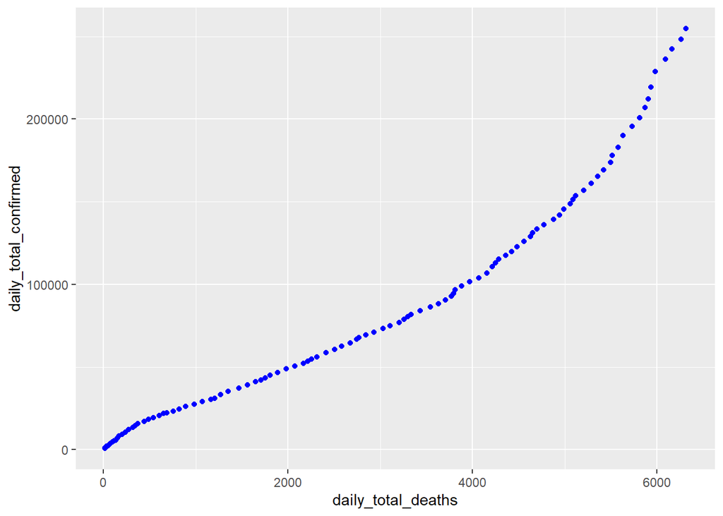

## Baseline linear modeling

People don’t die when they are confirmed as COVID positive [^2]. Death generally occurs at some interval after testing. Deaths can be predicted from confirmed cases using a simple linear model.

Using the unaltered data, the linear model has very significant R vale

```r
### R value. R^2 taken from Summary
sqrt(.9467) ## R=.9729851
```

```
## [1] 0.9729851
```

Visually, we can tell the baseline model isn’t very helpful in predicting deaths based on confirmed cases, Correlation is not causation.

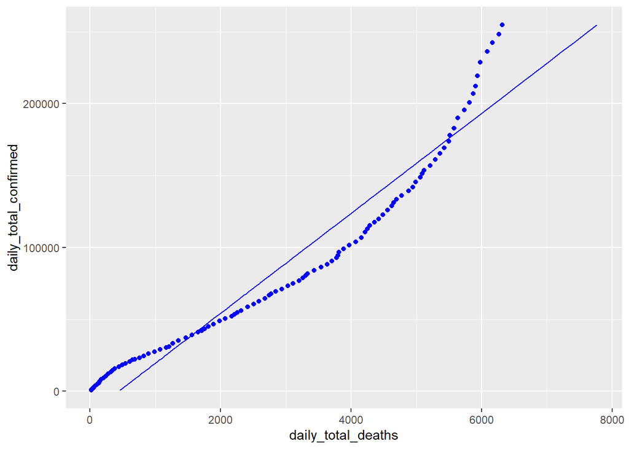